# Project 2 - MLR with Confounding and Interaction (SAS)

# Filtering Data Set

Now let’s take a look at the header to get a good feeling for our data.

```sas
* Print head of data;
PROC PRINT DATA = Proj2.raw_data (OBS = 10);
  RUN;
```

**lst**

The SAS System

| Obs | newid | AGG_MENT | AGG_PHYS | HASHV | BMI | HBP | DIAB | LIV34 | KID | FRP | FP | TCHOL | TRIG | LDL | DYSLIP | CESD | SMOKE | DKGRP | HEROPIATE | IDU | LEU3N | VLOAD | RACE | EDUCBAS | hivpos | age | ART | everART | years | … |
| --- | --- | --- | --- | --- | --- | --- | --- | --- | --- | --- | --- | --- | --- | --- | --- | --- | --- | --- | --- | --- | --- | --- | --- | --- | --- | --- | --- | --- | --- | --- |
| 1 | 1 | 44.90709633 | 52.52556921 | 1 | 24.71755909 | 1 | 1 | 1 | 1 | 1 | 1 | 133 | 176 | 62 | 2 | 14 | 3 | 0 | 1 | 2 | 104.1659454 | 102013 | 1 | 4 | 1 | 52 | 0 | 0 | 0 | … |
| 2 | 1 | 58.20753602 | 41.29346502 | 1 | 26.06800717 | 1 | 1 | 1 | 1 | 1 | 1 | 131 | 107 | 66 | 1 | 2 | 3 | 3 | 1 | 1 | 262.0060502 | 27 | 1 | 4 | 1 | 53 | 1 | 1 | 1 | … |
| 3 | 1 | 59.65135974 | 48.54453213 | 1 | 27.16420923 | 1 | 1 | 1 | 1 | 1 | 1 | 180 | 233 | 86 | 2 | 1 | 3 | 0 | 1 | 1 | 345.4009918 | 60 | 1 | 4 | 1 | 54 | 1 | 1 | 2 | … |
| 4 | 1 | 56.806574 | 46.73991355 | 1 | 25.71785653 | 1 | 1 | 1 | 1 | 1 | 1 | 171 | 139 | 96 | 1 | 18 | 3 | 1 | 1 | 1 | 292.3271358 | 9 | 1 | 4 | 1 | 55 | 1 | 1 | 3 | … |
| 5 | 2 | 46.34189863 | 27.92331491 | 1 | 26.66936015 | 2 | 9 | 1 | 9 | 2 | 9 | 125 | NA | NA | 2 | 20 | 3 | 0 | 1 | 2 | 257.8277832 | 8121 | 3 | 2 | 1 | 54 | 0 | 0 | 0 | … |
| 6 | 2 | 48.71790642 | 38.03806704 | 2 | 25.96576195 | 2 | 9 | 1 | 9 | 1 | 9 | NA | NA | NA | 9 | 18 | 3 | 3 | 1 | 1 | 459.4561691 | 21 | 3 | 2 | 1 | 55 | 1 | 1 | 1 | … |
| 7 | 2 | 45.41482533 | 37.32203958 | 1 | 26.96036793 | 2 | 9 | 1 | 9 | 1 | 1 | 134 | NA | NA | 4 | 18 | 3 | 2 | 1 | 1 | 263.0692533 | 48 | 3 | 2 | 1 | 56 | 1 | 1 | 2 | … |
| 8 | 2 | 48.05706234 | 31.80529414 | 2 | 27.56218329 | 2 | 1 | 1 | 2 | 1 | 1 | 105 | 104 | 44 | 1 | 21 | 3 | 1 | 1 | 1 | 238.6691021 | 20 | 3 | 2 | 1 | 60 | 1 | 1 | 6 | … |
| 9 | 2 | 48.53362078 | 42.05479171 | 1 | 27.55110061 | 2 | 1 | 1 | 2 | 1 | 1 | 141 | 162 | 73 | 2 | 23 | 3 | 0 | 1 | 1 | 253.8642976 | 32 | 3 | 2 | 1 | 61 | 1 | 1 | 7 | … |
| 10 | 2 | 58.60481316 | 34.22034136 | 2 | 27.08387053 | 2 | 1 | 1 | 2 | 1 | 1 | 153 | 127 | 84 | 1 | 17 | 3 | 1 | 1 | 1 | 246.1489785 | 70 | 3 | 2 | 1 | 62 | 1 | 1 | 8 | … |

**log**

[output not shown]

Hmm, we have 8 years worth of data points, but the experimenters are only interested in the first 2 years.

Out of curiosity, let’s look at how many participants they had each year.

```sas
* Create a dataset to count the number of patients per year;
PROC FREQ DATA=Proj2.data;
    TABLES years / OUT=year_counts;
RUN;

* Plot the bar chart;
PROC SGPLOT DATA=year_counts;
    VBAR years / RESPONSE=COUNT;
    XAXIS LABEL="Year of Study";
    YAXIS LABEL="Number of Patients";
    TITLE "Patient Drop-off Over 8 Years of Study";
RUN;

TITLE;
```

**lst**

The SAS System

The FREQ Procedure

| years | Frequency | Percent | Cumulative Frequency | Cumulative Percent |
| --- | --- | --- | --- | --- |
| 0 | 550 | 15.14 | 550 | 15.14 |
| 1 | 550 | 15.14 | 1100 | 30.29 |
| 2 | 550 | 15.14 | 1650 | 45.43 |
| 3 | 414 | 11.40 | 2064 | 56.83 |
| 4 | 381 | 10.49 | 2445 | 67.32 |
| 5 | 338 | 9.31 | 2783 | 76.62 |
| 6 | 325 | 8.95 | 3108 | 85.57 |
| 7 | 272 | 7.49 | 3380 | 93.06 |
| 8 | 252 | 6.94 | 3632 | 100.00 |

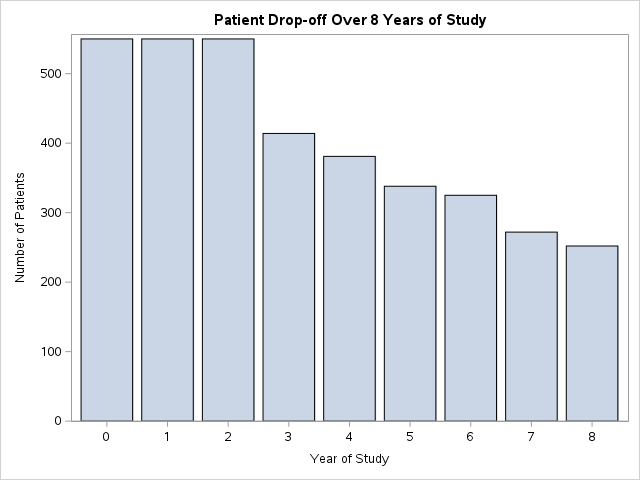

**log**

[output not shown]

Let’s filter to only include values from the first 2 years, as this is the timeframe the researchers are interested in.

```sas
* Filter data set to only first 2 years;
DATA Proj2.data2;
  SET Proj2.data;
  IF years <= 2;
  RUN;

* Get length of filtered data set;
PROC SQL;
  SELECT COUNT(*) AS num_rows
  FROM Proj2.data2;
QUIT;
```

**lst**

| num_rows |
| --- |
| 1650 |

**log**

[output not shown]

We went from 3632 visits in the 8 year data set to 1650 in the 2 year filtered data set.

## Transpose to Wideform

We can also see that the provided data set is in longform. Let’s convert that to wideform.

```sas
PROC SORT DATA = Proj2.data2;
  BY years newid;
  RUN;

* Transpose the data out of wide format into long format;
PROC TRANSPOSE DATA=Proj2.data2 OUT=Proj2.data_wide_2 PREFIX=Year;
    BY years;
    ID newid;
    VAR _ALL_;
RUN;

PROC PRINT DATA = Proj2.data_wide_2 (OBS = 100);
      RUN;
```

**lst**

| Obs | years | *NAME* | *LABEL* | Year1 | Year2 | Year3 | Year4 | Year5 | Year6 | Year7 | Year8 | Year9 | Year10 | Year11 | Year12 | Year13 | Year14 | Year15 | Year16 | Year17 | Year18 | Year19 | Year20 | Year21 | Year22 | Year23 | Year24 | Year25 | Year26 | … |
| --- | --- | --- | --- | --- | --- | --- | --- | --- | --- | --- | --- | --- | --- | --- | --- | --- | --- | --- | --- | --- | --- | --- | --- | --- | --- | --- | --- | --- | --- | --- |
| 1 | 0 | newid | ID | 1 | 2 | 3 | 4 | 5 | 6 | 7 | 8 | 9 | 10 | 11 | 12 | 13 | 14 | 15 | 16 | 17 | 18 | 19 | 20 | 21 | 22 | 23 | 24 | 25 | 26 | … |
| 2 | 0 | AGG_MENT | Aggregate Mental QOL Score | 44.90709633 | 46.34189863 | 40.22336832 | 42.9063758 | 56.42904322 | 59.74437147 | 48.90463502 | 49.47258363 | 45.53638994 | 39.68873012 | 20.6560246 | 54.81455227 | 28.85739466 | 25.40110088 | 56.64555861 | 55.27925182 | 60.20028926 | 30.50618267 | 29.23291201 | 41.74346997 | 14.49701143 | 47.8433612 | 44.64371009 | 36.95605011 | 57.26127545 | 55.90154007 | … |
| 3 | 0 | AGG_PHYS | Aggregate Physical QOL Score | 52.52556921 | 27.92331491 | 60.06969568 | 50.7885018 | 43.75671037 | 56.86260913 | 52.78791763 | 55.23964561 | 47.73831907 | 48.18627251 | 60.319661 | 45.43126292 | 53.70117805 | 43.38554764 | 51.80922475 | 54.40453498 | 47.778456 | 57.52488289 | 29.67280338 | 57.74035835 | 65.48612341 | 51.10825454 | 27.9915838 | 63.8495274 | 40.38870398 | 60.0360685 | … |
| 4 | 0 | HASHV | Frequency of Hash/Marijuana Use | 1 | 1 | 1 | 2 | 1 | 1 | 1 | 1 | 2 | 2 | 1 | 2 | 2 | 1 | 1 | 2 | 2 | 1 | 1 | 2 | 2 | 1 | 1 | 1 | 1 | 1 | … |
| 5 | 0 | BMI | BMI | 24.71755909 | 26.66936015 | 28.59084821 | 20.36451325 | 22.2698601 | 23.22165848 | 24.71687978 | 28.85804285 | 19.91076684 | 20.59908544 | 18.55779905 | 20.41588386 | 22.59478671 | 24.76099529 | 23.50498072 | 28.49781375 | 22.40198052 | 25.57984025 | 30.28356289 | . | 29.38139815 | 26.46393147 | 28.18114908 | 29.87478411 | 22.41865037 | 22.95171446 | … |
| 6 | 0 | HBP | High Blood Pressure | 1 | 2 | 9 | 1 | 1 | 1 | 9 | 9 | 1 | 1 | 2 | 1 | 1 | 1 | 2 | 1 | 1 | 1 | 2 | 1 | 1 | 1 | 2 | 9 | 1 | 1 | … |
| 7 | 0 | DIAB | Diabetes | 1 | 9 | 9 | 1 | 9 | 9 | 9 | 9 | 1 | 9 | 9 | 3 | 1 | 1 | 2 | 9 | 9 | 1 | 1 | 2 | 1 | 1 | 9 | 9 | 9 | 9 | … |
| 8 | 0 | LIV34 | Liver Disease Stage 3/4 | 1 | 1 | 1 | 1 | 1 | 1 | 1 | 1 | 1 | 1 | 1 | 2 | 2 | 1 | 1 | 9 | 1 | 1 | 1 | 1 | 1 | 1 | 1 | 1 | 1 | 1 | … |
| 9 | 0 | KID | Kidney Disease | 1 | 9 | 1 | 9 | 9 | 1 | 1 | 1 | 1 | 9 | 9 | 2 | 9 | 9 | 2 | 9 | 1 | 1 | 9 | 1 | 1 | 1 | 9 | 1 | 9 | 1 | … |
| 10 | 0 | FRP | Frailty Related Phenotype | 1 | 2 | 1 | 1 | 1 | 1 | 1 | 1 | 1 | 1 | 1 | 1 | 1 | 1 | 1 | 1 | 1 | 1 | 1 | 1 | 1 | 1 | 2 | 1 | 1 | 1 | … |
| 11 | 0 | FP | Frailty Phenotype | 1 | 9 | 1 | 1 | 9 | 1 | 1 | 1 | 1 | 9 | 1 | 1 | 1 | 9 | 1 | 1 | 1 | 1 | 9 | 1 | 1 | 1 | 9 | 1 | 9 | 1 | … |
| 12 | 0 | TCHOL | Total Cholesterol | 133 | 125 | 170 | 214 | 196 | 216 | NA | NA | 167 | NA | 98 | 98 | 178 | 132 | NA | NA | 182 | 165 | 196 | 150 | 264 | 133 | 125 | 170 | 196 | 216 | … |
| 13 | 0 | TRIG | Triglycerides | 176 | NA | NA | 97 | 162 | NA | NA | NA | 71 | NA | NA | NA | 141 | 72 | NA | NA | NA | 48 | 160 | 80 | 167 | 176 | NA | NA | 162 | NA | … |
| 14 | 0 | LDL | LDL | 62 | NA | NA | 147 | 135 | NA | NA | NA | 113 | NA | NA | NA | 101 | 75 | NA | NA | NA | 105 | 704 | 84 | 169 | 62 | NA | NA | 135 | NA | … |
| 15 | 0 | DYSLIP | Dyslipidemia | 2 | 2 | 2 | 2 | 2 | 9 | 9 | 9 | 1 | 9 | 2 | 9 | 1 | 1 | 9 | 9 | 9 | 1 | 2 | 1 | 2 | 2 | 2 | 2 | 2 | 9 | … |
| 16 | 0 | CESD | CESD Depression Score | 14 | 20 | 18 | 14 | 1 | 3 | 9 | 10 | 8 | 21 | 18 | 17 | 31 | 30 | 2 | -1 | 6 | 25 | 27 | 32 | 28 | 14 | 20 | 18 | 1 | 3 | … |
| 17 | 0 | SMOKE | Smoking Status | 3 | 3 | 2 | 3 | 3 | 1 | 2 | 3 | 2 | 3 | 3 | 3 | 2 | 3 | 3 | 2 | 3 | 3 | 3 | 3 | 1 | 3 | 3 | 2 | 3 | 1 | … |
| 18 | 0 | DKGRP | Drinking Group | 0 | 0 | 0 | 1 | 0 | 1 | 1 | 3 | 1 | 1 | 0 | 2 | 1 | 2 | 3 | 2 | 0 | 0 | 1 | 2 | 0 | 0 | 1 | 1 | 1 | 2 | … |
| 19 | 0 | HEROPIATE | Heroin or Opiate Use Since Last Visit | 1 | 1 | 1 | 2 | -9 | 1 | 1 | . | 1 | 1 | 2 | 2 | 1 | 1 | 1 | 1 | 2 | 2 | 2 | 1 | 1 | 1 | 1 | 1 | -9 | 1 | … |
| 20 | 0 | IDU | Intravenous Drug Usage Since Last Visit | 2 | 2 | 2 | 1 | 2 | 1 | 1 | 2 | 2 | 2 | 1 | 2 | 2 | 2 | 1 | 1 | 2 | 1 | 1 | 1 | 1 | 2 | 2 | 2 | 2 | 1 | … |
| 21 | 0 | LEU3N | CD4+ T Cell Count | 104.1659454 | 257.8277832 | 563.1222984 | 110.4217933 | 252.6633917 | 634.1246084 | 917.9889891 | 552.9199764 | 459.5461372 | 186.7824358 | 342.9786179 | 98.6546825 | 575.4565738 | 648.0937554 | 514.0510529 | 538.88494 | 461.4120531 | 266.2782621 | 11.88947635 | 552.6720921 | 792.5264499 | 106.9620041 | 257.6113134 | 560.3858688 | 249.8670905 | 634.4245812 | … |
| 22 | 0 | VLOAD | Viral Load;*';* | 102013 | 8121 | 4001.556158 | 740 | 62727.03871 | 15745 | 35171 | 326013 | 13827.21219 | 684562 | 5605 | 12919 | 29274 | 293885 | 16807 | 14359 | 27428 | 1894 | 2515706 | 1102 | 16599 | 102006 | 8121 | 3999.583382 | 44526.19366 | 15760 | … |
| 23 | 0 | RACE |  | 1 | 3 | 1 | 1 | 1 | 1 | 7 | 1 | 1 | 3 | 3 | 3 | 8 | 3 | 3 | 1 | 1 | 3 | 3 | 3 | 1 | 1 | 3 | 1 | 1 | 1 | … |
| 24 | 0 | EDUCBAS |  | 4 | 2 | 7 | 5 | 7 | 6 | 5 | 4 | 7 | 2 | 2 | 2 | 2 | 4 | 4 | 6 | 4 | 3 | 4 | 4 | 4 | 4 | 2 | 7 | 7 | 6 | … |
| 25 | 0 | hivpos |  | 1 | 1 | 1 | 1 | 1 | 1 | 1 | 1 | 1 | 1 | 1 | 1 | 1 | 1 | 1 | 1 | 1 | 1 | 1 | 1 | 1 | 1 | 1 | 1 | 1 | 1 | … |
| 26 | 0 | age |  | 52 | 54 | 47 | 44 | 53 | 36 | 47 | 30 | 47 | 40 | 32 | 53 | 29 | 40 | 50 | 51 | 38 | 61 | 36 | 51 | 39 | 53 | 51 | 48 | 54 | 36 | … |
| 27 | 0 | ART |  | 0 | 0 | 0 | 0 | 0 | 0 | 0 | 0 | 0 | 0 | 0 | 0 | 0 | 0 | 0 | 0 | 0 | 0 | 0 | 0 | 0 | 0 | 0 | 0 | 0 | 0 | … |
| 28 | 0 | everART |  | 0 | 0 | 0 | 0 | 0 | 0 | 0 | 0 | 0 | 0 | 0 | 0 | 0 | 0 | 0 | 0 | 0 | 0 | 0 | 0 | 0 | 0 | 0 | 0 | 0 | 0 | … |
| 29 | 0 | years |  | 0 | 0 | 0 | 0 | 0 | 0 | 0 | 0 | 0 | 0 | 0 | 0 | 0 | 0 | 0 | 0 | 0 | 0 | 0 | 0 | 0 | 0 | 0 | 0 | 0 | 0 | … |
| 30 | 0 | hard_drugs |  | 1 | 1 | 1 | 1 | 1 | 0 | 0 | 1 | 1 | 1 | 1 | 1 | 1 | 1 | 0 | 0 | 1 | 1 | 1 | 0 | 0 | 1 | 1 | 1 | 1 | 0 | … |

[output cut: 69 more lines]

**log**

[output not shown]